# Predicting House Price

Cameron Greenwalt, John Graff, Mitchell Rands

# Background and introduction.

The real estate market presents an interesting opportunity for data analysts to analyze and predict where property prices are moving towards. Prediction of property prices is becoming increasingly important and beneficial. Property prices are a good indicator of both the overall market condition and the economic health of a country. Considering the data provided, we are wrangling a large set of property sales records stored in an unknown format and with unknown data quality issues.

Being able to predict house prices would be beneficial for those trying to sell and trying to buy. Those looking to sell could put in the specifications of their house and see how much they could be expecting to receive and for those buying they can see what they want in a house and how much that will cost them.

To test these assumptions, we obtained 4600 data entrees for houses that sold. We will begin our analysis by applying basic summary statistics and exploratory data techniques to better understand the data. Then, we apply multiple linear regression with price as the response, regressed on the other variables in the data set.

| Variable | Description |
| --- | --- |
| Price | the price the house sold for. (Response variable) |
| Bedrooms | the number of bedrooms in the house |
| Bathrooms | number of bathrooms in the house |
| sqft_living | amount of living square footage |
| Sqft_lot | total square footage |
| floors | number of floors in the house |
| Waterfront | if the house is waterfront |
| View | view the house received |
| Condition | condition of the house |
| Square above | square footage above ground |
| Square base | square footage of the basement |
| Year built | year built |
| Year Renovated | if the house has been renovated. |

The first thing we will do is load the dataset and print a summary.

```r
house <- read.csv("house.csv", header = TRUE, sep = ",")
# head(house)

# remove date and location columns
house <- house[, c(2, 3, 4, 5, 6, 7, 8, 9, 10, 11, 12, 13, 14)]
head(house)
```

```
##     price bedrooms bathrooms sqft_living sqft_lot floors waterfront view
## 1  313000        3      1.50        1340     7912    1.5          0    0
## 2 2384000        5      2.50        3650     9050    2.0          0    4
## 3  342000        3      2.00        1930    11947    1.0          0    0
## 4  420000        3      2.25        2000     8030    1.0          0    0
## 5  550000        4      2.50        1940    10500    1.0          0    0
## 6  490000        2      1.00         880     6380    1.0          0    0
##   condition sqft_above sqft_basement yr_built yr_renovated
## 1         3       1340             0     1955         2005
## 2         5       3370           280     1921            0
## 3         4       1930             0     1966            0
## 4         4       1000          1000     1963            0
## 5         4       1140           800     1976         1992
## 6         3        880             0     1938         1994
```

```r
summary(house)
```

```
##      price             bedrooms       bathrooms      sqft_living
##  Min.   :       0   Min.   :0.000   Min.   :0.000   Min.   :  370
##  1st Qu.:  322875   1st Qu.:3.000   1st Qu.:1.750   1st Qu.: 1460
##  Median :  460943   Median :3.000   Median :2.250   Median : 1980
##  Mean   :  551963   Mean   :3.401   Mean   :2.161   Mean   : 2139
##  3rd Qu.:  654962   3rd Qu.:4.000   3rd Qu.:2.500   3rd Qu.: 2620
##  Max.   :26590000   Max.   :9.000   Max.   :8.000   Max.   :13540
##     sqft_lot           floors        waterfront            view
##  Min.   :    638   Min.   :1.000   Min.   :0.000000   Min.   :0.0000
##  1st Qu.:   5001   1st Qu.:1.000   1st Qu.:0.000000   1st Qu.:0.0000
##  Median :   7683   Median :1.500   Median :0.000000   Median :0.0000
##  Mean   :  14852   Mean   :1.512   Mean   :0.007174   Mean   :0.2407
##  3rd Qu.:  11001   3rd Qu.:2.000   3rd Qu.:0.000000   3rd Qu.:0.0000
##  Max.   :1074218   Max.   :3.500   Max.   :1.000000   Max.   :4.0000
##    condition       sqft_above   sqft_basement       yr_built
##  Min.   :1.000   Min.   : 370   Min.   :   0.0   Min.   :1900
##  1st Qu.:3.000   1st Qu.:1190   1st Qu.:   0.0   1st Qu.:1951
##  Median :3.000   Median :1590   Median :   0.0   Median :1976
##  Mean   :3.452   Mean   :1827   Mean   : 312.1   Mean   :1971
##  3rd Qu.:4.000   3rd Qu.:2300   3rd Qu.: 610.0   3rd Qu.:1997
##  Max.   :5.000   Max.   :9410   Max.   :4820.0   Max.   :2014
##   yr_renovated
##  Min.   :   0.0
##  1st Qu.:   0.0
##  Median :   0.0
##  Mean   : 808.6
##  3rd Qu.:1999.0
##  Max.   :2014.0
```

Next, we will change the approprate predictors to factors.

```r
# Since the original data treats them as 0,1 we will change to no/yes for interpretability
house$waterfront <- ifelse(house$waterfront == 0, "no", "yes")
house$waterfront <- as.factor(house$waterfront)

house$view <- as.factor(house$view)

house$condition <- as.factor(house$condition)

# Change yr_renovated as yes/no
house$yr_renovated <- ifelse(house$yr_renovated == 0, "no", "yes")
house$yr_renovated <- as.factor(house$yr_renovated)
house$renovated <- house$yr_renovated

# Remove the yr_renovated column
house <- house[, -13] # removes yr_renovated column

head(house)
```

```
##     price bedrooms bathrooms sqft_living sqft_lot floors waterfront view
## 1  313000        3      1.50        1340     7912    1.5         no    0
## 2 2384000        5      2.50        3650     9050    2.0         no    4
## 3  342000        3      2.00        1930    11947    1.0         no    0
## 4  420000        3      2.25        2000     8030    1.0         no    0
## 5  550000        4      2.50        1940    10500    1.0         no    0
## 6  490000        2      1.00         880     6380    1.0         no    0
##   condition sqft_above sqft_basement yr_built renovated
## 1         3       1340             0     1955       yes
## 2         5       3370           280     1921        no
## 3         4       1930             0     1966        no
## 4         4       1000          1000     1963        no
## 5         4       1140           800     1976       yes
## 6         3        880             0     1938       yes
```

```r
summary(house)
```

```
##      price             bedrooms       bathrooms      sqft_living
##  Min.   :       0   Min.   :0.000   Min.   :0.000   Min.   :  370
##  1st Qu.:  322875   1st Qu.:3.000   1st Qu.:1.750   1st Qu.: 1460
##  Median :  460943   Median :3.000   Median :2.250   Median : 1980
##  Mean   :  551963   Mean   :3.401   Mean   :2.161   Mean   : 2139
##  3rd Qu.:  654962   3rd Qu.:4.000   3rd Qu.:2.500   3rd Qu.: 2620
##  Max.   :26590000   Max.   :9.000   Max.   :8.000   Max.   :13540
##     sqft_lot           floors      waterfront view     condition   sqft_above
##  Min.   :    638   Min.   :1.000   no :4567   0:4140   1:   6    Min.   : 370
##  1st Qu.:   5001   1st Qu.:1.000   yes:  33   1:  69   2:  32    1st Qu.:1190
##  Median :   7683   Median :1.500              2: 205   3:2875    Median :1590
##  Mean   :  14852   Mean   :1.512              3: 116   4:1252    Mean   :1827
##  3rd Qu.:  11001   3rd Qu.:2.000              4:  70   5: 435    3rd Qu.:2300
##  Max.   :1074218   Max.   :3.500                                 Max.   :9410
##  sqft_basement       yr_built    renovated
##  Min.   :   0.0   Min.   :1900   no :2735
##  1st Qu.:   0.0   1st Qu.:1951   yes:1865
##  Median :   0.0   Median :1976
##  Mean   : 312.1   Mean   :1971
##  3rd Qu.: 610.0   3rd Qu.:1997
##  Max.   :4820.0   Max.   :2014
```

```r
house.lm <- lm(house)
summary(house.lm)
```

```
##
## Call:
## lm(formula = house)
##
## Residuals:
##      Min       1Q   Median       3Q      Max
## -2144507  -127727   -16016    89537 26335658
##
## Coefficients: (1 not defined because of singularities)
##                 Estimate Std. Error t value Pr(>|t|)
## (Intercept)    4.613e+06  6.996e+05   6.593 4.80e-11 ***
## bedrooms      -5.794e+04  1.051e+04  -5.513 3.71e-08 ***
## bathrooms      5.571e+04  1.707e+04   3.264 0.001108 **
## sqft_living    2.309e+02  2.170e+01  10.639  < 2e-16 ***
## sqft_lot      -6.805e-01  2.135e-01  -3.188 0.001441 **
## floors         3.954e+04  1.885e+04   2.098 0.035974 *
## waterfrontyes  4.059e+05  9.998e+04   4.059 5.00e-05 ***
## view1          1.693e+05  6.128e+04   2.764 0.005741 **
## view2          7.439e+04  3.684e+04   2.019 0.043524 *
## view3          1.826e+05  4.870e+04   3.750 0.000179 ***
## view4          1.103e+05  7.053e+04   1.563 0.118007
## condition2    -2.438e+04  2.223e+05  -0.110 0.912661
## condition3     4.431e+04  2.052e+05   0.216 0.829055
## condition4     7.175e+04  2.048e+05   0.350 0.726069
## condition5     1.091e+05  2.055e+05   0.531 0.595658
## sqft_above     3.050e+01  2.161e+01   1.411 0.158206
## sqft_basement         NA         NA      NA       NA
## yr_built      -2.365e+03  3.489e+02  -6.778 1.38e-11 ***
## renovatedyes   1.076e+04  1.772e+04   0.607 0.543669
## ---
## Signif. codes:  0 '***' 0.001 '**' 0.01 '*' 0.05 '.' 0.1 ' ' 1
##
## Residual standard error: 499200 on 4582 degrees of freedom
## Multiple R-squared:  0.2189, Adjusted R-squared:  0.216
## F-statistic: 75.56 on 17 and 4582 DF,  p-value: < 2.2e-16
```

Bedrooms, bathrooms, and floors are all discrete variables. In this analysis, we will treat them as continuous. However, we will make a new dataframe with noise added to these variables for better visualization of the overall trend.

```r
house.jitter <- house

house.jitter$bedrooms <- jitter(house$bedrooms, factor = 2.5)
house.jitter$bathrooms <- jitter(house$bathrooms, factor = 5)
house.jitter$floors <- jitter(house$floors, factor = 5)
```

We will remove houses with a price of 0 for later use in best subsets and logging the response variable.

```r
house <- house[!(house$price == 0),]
house.jitter <- house.jitter[!(house.jitter$price == 0),]
```

# Perfom variable selection to narrow down predictor variables

Since we have categorical variables with more than two levels, the regsubsets function will be used. BIC will be our metric cutoff.

```r
regsubsets.out <-
    regsubsets(price ~ .,
               data = house,
               nbest = 1,       # 1 best model for each number of predictors
               nvmax = NULL,    # NULL for no limit on number of variables
               force.in = NULL, force.out = NULL,
               method = "exhaustive")
```

```
## Reordering variables and trying again:
```

```r
regsubsets.out
```

```
## Subset selection object
## Call: regsubsets.formula(price ~ ., data = house, nbest = 1, nvmax = NULL,
##     force.in = NULL, force.out = NULL, method = "exhaustive")
## 18 Variables  (and intercept)
##               Forced in Forced out
## bedrooms          FALSE      FALSE
## bathrooms         FALSE      FALSE
## sqft_living       FALSE      FALSE
## sqft_lot          FALSE      FALSE
## floors            FALSE      FALSE
## waterfrontyes     FALSE      FALSE
## view1             FALSE      FALSE
## view2             FALSE      FALSE
## view3             FALSE      FALSE
## view4             FALSE      FALSE
## condition2        FALSE      FALSE
## condition3        FALSE      FALSE
## condition4        FALSE      FALSE
## condition5        FALSE      FALSE
## sqft_above        FALSE      FALSE
## yr_built          FALSE      FALSE
## renovatedyes      FALSE      FALSE
## sqft_basement     FALSE      FALSE
## 1 subsets of each size up to 17
## Selection Algorithm: exhaustive
```

This prints the summary of the best models and which predictors were included in each model. Each row down includes one more predictor variable than the last.

```r
summary.out <- summary(regsubsets.out)
head(as.data.frame(summary.out$outmat), 10) # Only show the top 10 models
```

```
##           bedrooms bathrooms sqft_living sqft_lot floors waterfrontyes view1
## 1  ( 1 )                               *
## 2  ( 1 )                               *
## 3  ( 1 )                               *                             *
## 4  ( 1 )         *                     *                             *
## 5  ( 1 )         *         *           *                             *
## 6  ( 1 )         *         *           *        *                    *
## 7  ( 1 )         *         *           *        *                    *
## 8  ( 1 )         *         *           *        *                    *
## 9  ( 1 )         *         *           *        *                    *     *
## 10  ( 1 )        *         *           *        *                    *     *
##           view2 view3 view4 condition2 condition3 condition4 condition5
## 1  ( 1 )
## 2  ( 1 )
## 3  ( 1 )
```

[output cut: 18 more lines]

```r
# ## Adjusted R2
# plot(regsubsets.out, scale = "adjr2", main = "Adjusted R^2")
```

Here, we will plot the BIC relative to the number of predictors in the model. We want the model with the lowest BIC.

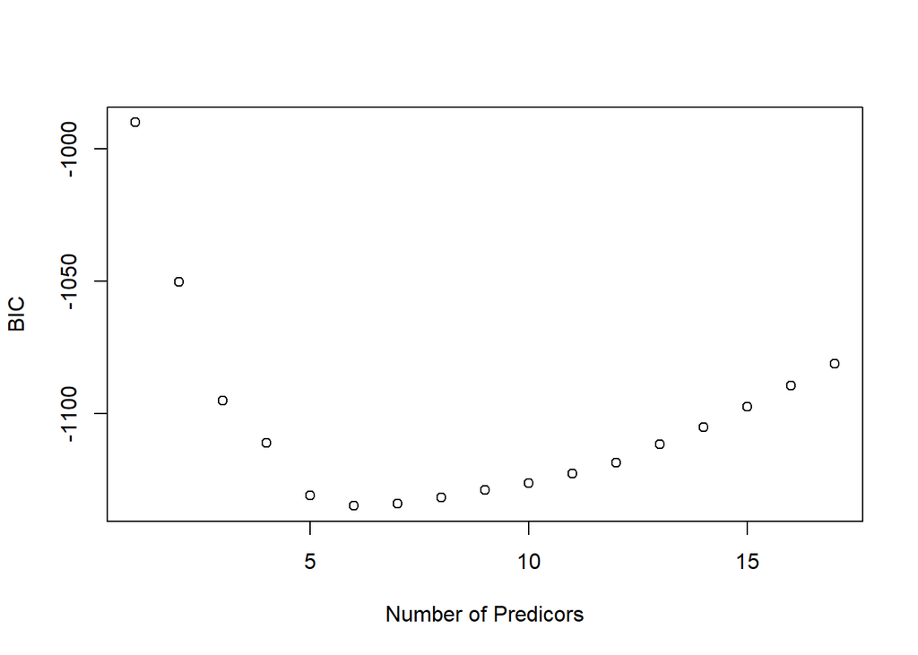

```r
plot(summary.out$bic,
     xlab="Number of Predicors",
     ylab="BIC")
```

```r
which.min(summary.out$bic)
```

```
## [1] 6
```

The 6th model in the table is the one with the lowest BIC, although that model contains sqft_lot, which, from external EDA, may cause lots of issues in meeting the linearity assumptions. Since the model with 5 predictors has a BIC not much different from the 6th model and leaves out sqft_lot, we will use that model.

Then, we’ll create a subset model with the included variables for the top 5 best models from the regsubsets method.

```r
house.subset <- subset(house, select = c(price, bedrooms, bathrooms, sqft_living,
                                         yr_built, waterfront))
house.jitter.subset <- subset(house.jitter,
                              select = c(price, bedrooms, bathrooms, sqft_living,
                                         yr_built, waterfront))
```

Next, we’ll create linear models for the selected variables

```r
house.subset.lm <- lm(house.subset)
summary(house.subset.lm)
```

```
##
## Call:
## lm(formula = house.subset)
##
## Residuals:
##      Min       1Q   Median       3Q      Max
## -1480872  -137247   -23776    89020 26333396
##
## Coefficients:
##                 Estimate Std. Error t value Pr(>|t|)
## (Intercept)   5378403.02  551146.02   9.759  < 2e-16 ***
## bedrooms       -62450.36   10409.89  -5.999 2.14e-09 ***
## bathrooms       86420.28   16169.91   5.345 9.51e-08 ***
## sqft_living       263.32      12.58  20.933  < 2e-16 ***
## yr_built        -2719.88     283.39  -9.598  < 2e-16 ***
## waterfrontyes  622257.46   91891.95   6.772 1.44e-11 ***
## ---
## Signif. codes:  0 '***' 0.001 '**' 0.01 '*' 0.05 '.' 0.1 ' ' 1
##
## Residual standard error: 495600 on 4545 degrees of freedom
## Multiple R-squared:  0.2287, Adjusted R-squared:  0.2278
## F-statistic: 269.5 on 5 and 4545 DF,  p-value: < 2.2e-16
```

```r
house.jitter.subset.lm <- lm(house.jitter.subset)
```

# CHECK MODEL ASSUMPTIONS

### Linearity

Here we will use the jitter subset for better visualization of trends.

#### Correlation Matrix

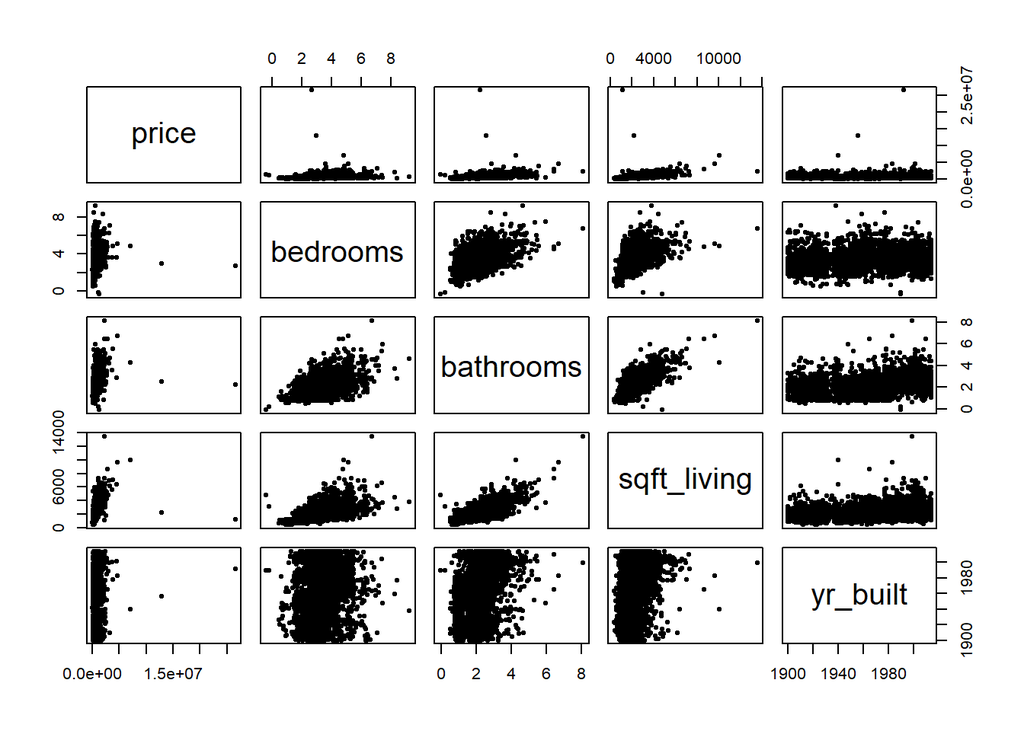

```r
pairs(house.jitter.subset[, c(1, 2, 3, 4, 5)], pch = 20)
```

#### Added-variable plots

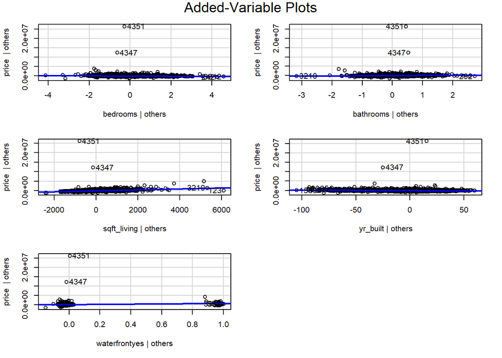

```r
avPlots(house.jitter.subset.lm)
```

#### Residuals vs Predictors

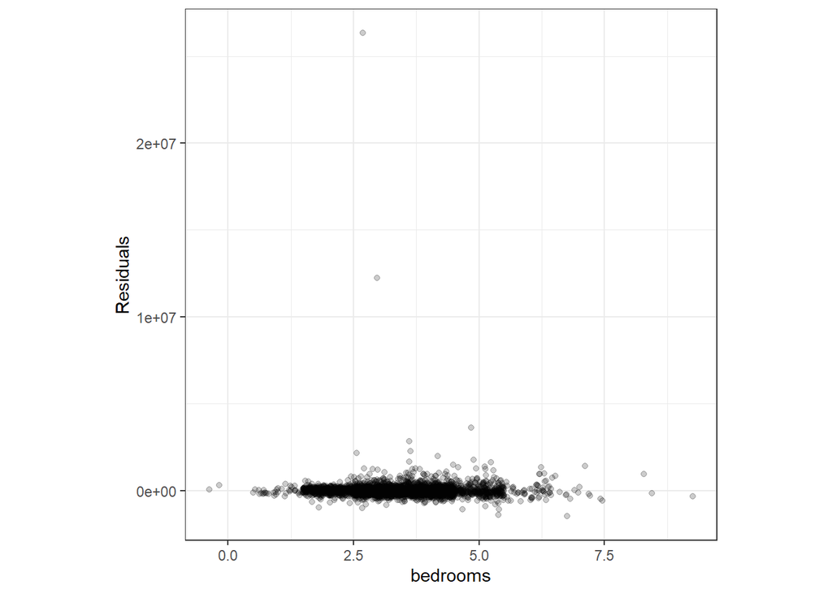

```r
ggplot(data = house.jitter.subset,
       mapping = aes(x = bedrooms, y = house.subset.lm$residuals)) +
  geom_point(alpha = 0.2) +
  theme_bw() +
  ylab("Residuals") +
  theme(aspect.ratio = 1)
```

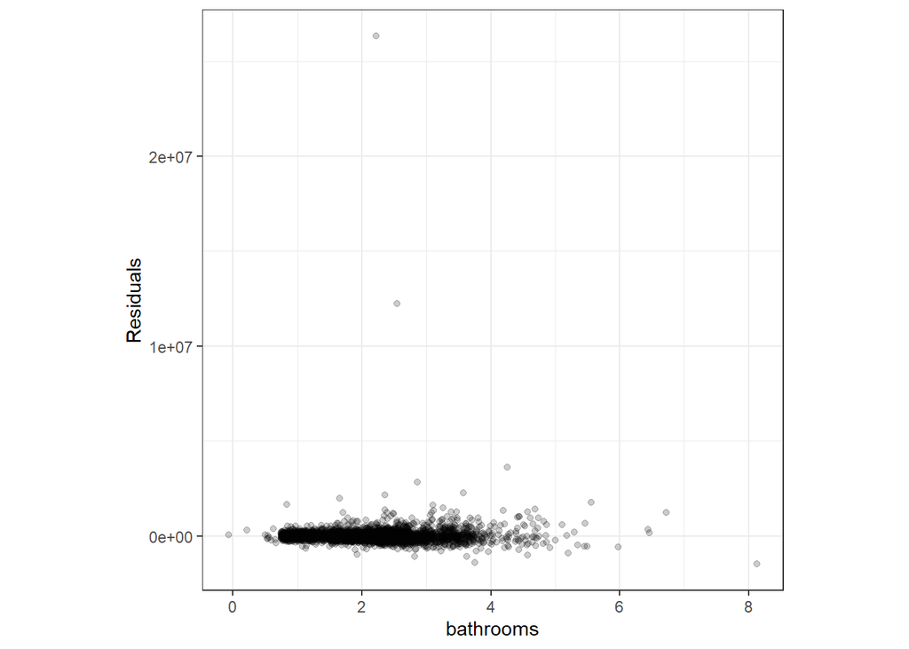

```r
ggplot(data = house.jitter.subset,
       mapping = aes(x = bathrooms, y = house.subset.lm$residuals)) +
  geom_point(alpha = 0.2) +
  theme_bw() +
  ylab("Residuals") +
  theme(aspect.ratio = 1)
```

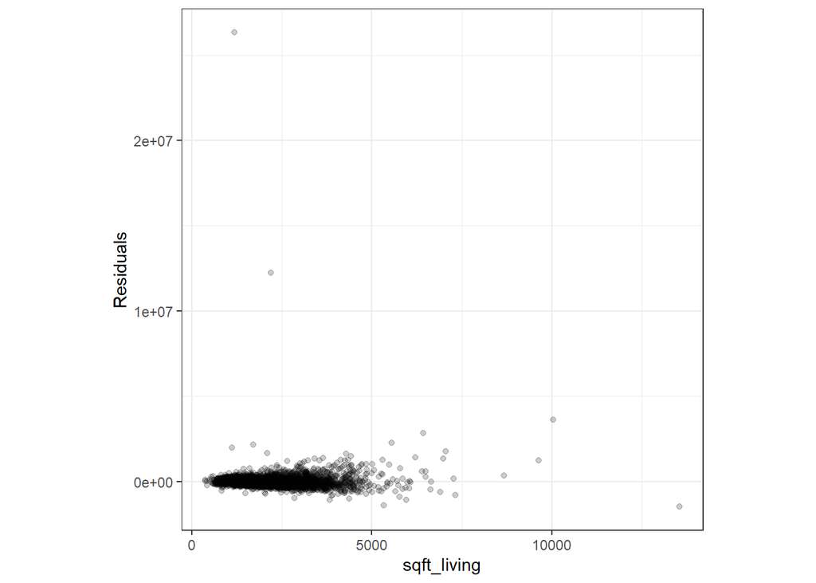

```r
ggplot(data = house.jitter.subset,
       mapping = aes(x = sqft_living, y = house.subset.lm$residuals)) +
  geom_point(alpha = 0.2) +
  theme_bw() +
  ylab("Residuals") +
  theme(aspect.ratio = 1)
```

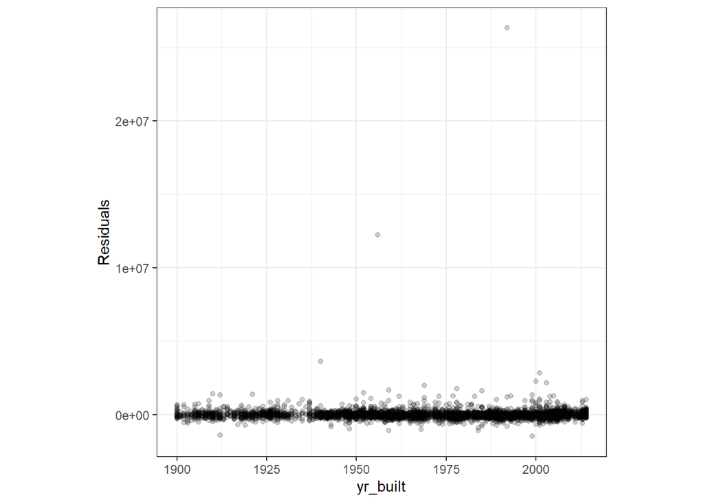

```r
ggplot(data = house.jitter.subset,
       mapping = aes(x = yr_built, y = house.subset.lm$residuals)) +
  geom_point(alpha = 0.2) +
  theme_bw() +
  ylab("Residuals") +
  theme(aspect.ratio = 1)
```

#### Residuals vs Fitted Values

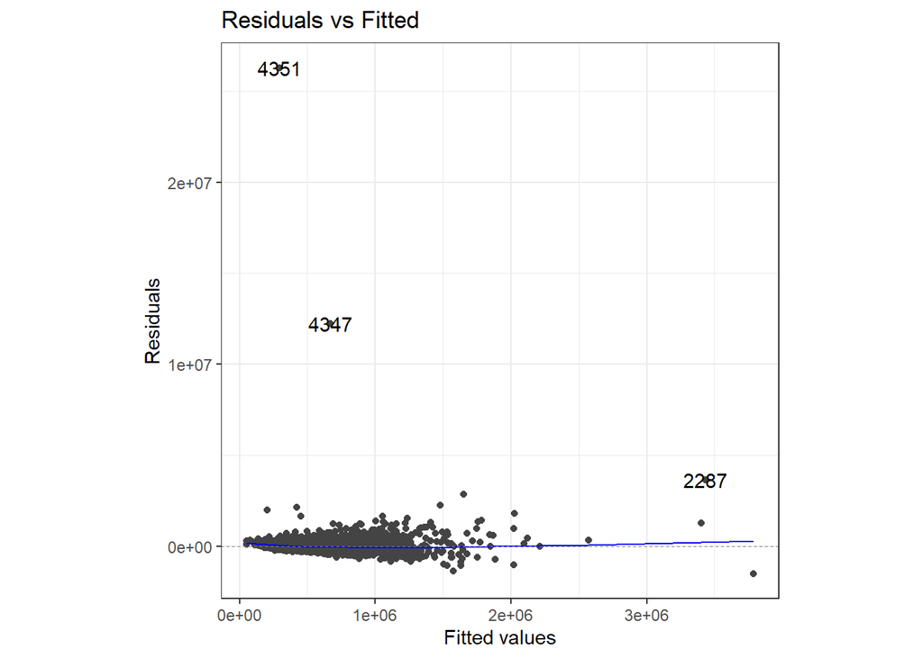

```r
autoplot(house.jitter.subset.lm,
         which = 1,
         ncol = 1,
         nrow = 1) + theme_bw() +
  theme(aspect.ratio = 1) +
  scale_y_continuous()
```

Before moving on, the residuals vs fitted values plot shows the variability in residuals is not consistent across all values of the domain. We will log the price, remake the linear model, and see what the assumptions look like then.

```r
house.subset$price <- log(house.subset$price)
house.subset.lm <- lm(house.subset)
summary(house.subset.lm)
```

```
##
## Call:
## lm(formula = house.subset)
##
## Residuals:
##     Min      1Q  Median      3Q     Max
## -3.6402 -0.2558  0.0338  0.2480  4.4425
##
## Coefficients:
##                 Estimate Std. Error t value Pr(>|t|)
## (Intercept)    1.970e+01  4.285e-01  45.981  < 2e-16 ***
## bedrooms      -6.547e-02  8.094e-03  -8.089 7.63e-16 ***
## bathrooms      1.700e-01  1.257e-02  13.525  < 2e-16 ***
## sqft_living    3.441e-04  9.780e-06  35.179  < 2e-16 ***
## yr_built      -3.815e-03  2.203e-04 -17.315  < 2e-16 ***
## waterfrontyes  3.613e-01  7.145e-02   5.057 4.43e-07 ***
## ---
## Signif. codes:  0 '***' 0.001 '**' 0.01 '*' 0.05 '.' 0.1 ' ' 1
##
## Residual standard error: 0.3853 on 4545 degrees of freedom
## Multiple R-squared:  0.4967, Adjusted R-squared:  0.4961
## F-statistic: 897.1 on 5 and 4545 DF,  p-value: < 2.2e-16
```

```r
house.jitter.subset$price <- log(house.jitter.subset$price)
house.jitter.subset.lm <- lm(house.jitter.subset)
summary(house.jitter.subset.lm)
```

```
##
## Call:
## lm(formula = house.jitter.subset)
##
## Residuals:
##     Min      1Q  Median      3Q     Max
## -3.6504 -0.2540  0.0352  0.2519  4.3938
##
## Coefficients:
##                 Estimate Std. Error t value Pr(>|t|)
## (Intercept)    1.946e+01  4.252e-01  45.763  < 2e-16 ***
## bedrooms      -5.722e-02  7.465e-03  -7.664 2.18e-14 ***
## bathrooms      1.533e-01  1.189e-02  12.894  < 2e-16 ***
## sqft_living    3.492e-04  9.503e-06  36.744  < 2e-16 ***
## yr_built      -3.693e-03  2.186e-04 -16.889  < 2e-16 ***
## waterfrontyes  3.583e-01  7.155e-02   5.007 5.73e-07 ***
## ---
## Signif. codes:  0 '***' 0.001 '**' 0.01 '*' 0.05 '.' 0.1 ' ' 1
##
## Residual standard error: 0.386 on 4545 degrees of freedom
## Multiple R-squared:  0.4949, Adjusted R-squared:  0.4943
## F-statistic: 890.5 on 5 and 4545 DF,  p-value: < 2.2e-16
```

Based on the adjusted R_squared, this model is much better overall than the previous one.

### Rechecking Linearity

#### Correlation Matrix

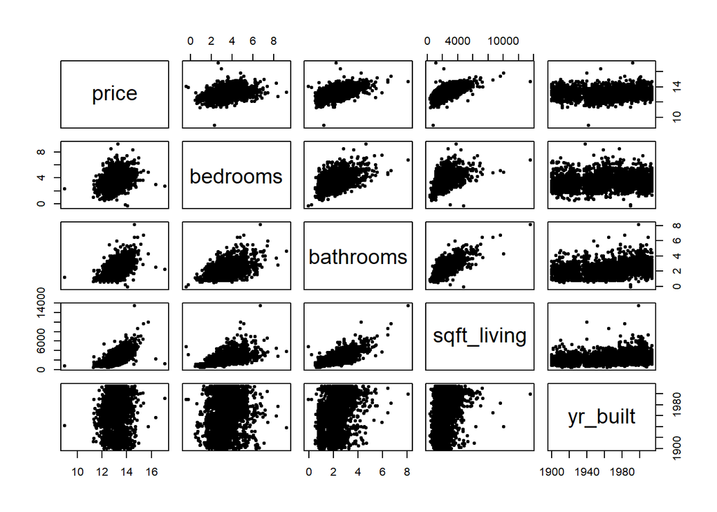

```r
# Correlation matrix
pairs(house.jitter.subset[, c(1, 2, 3, 4, 5)], pch = 20)
```

#### Added-variable plots

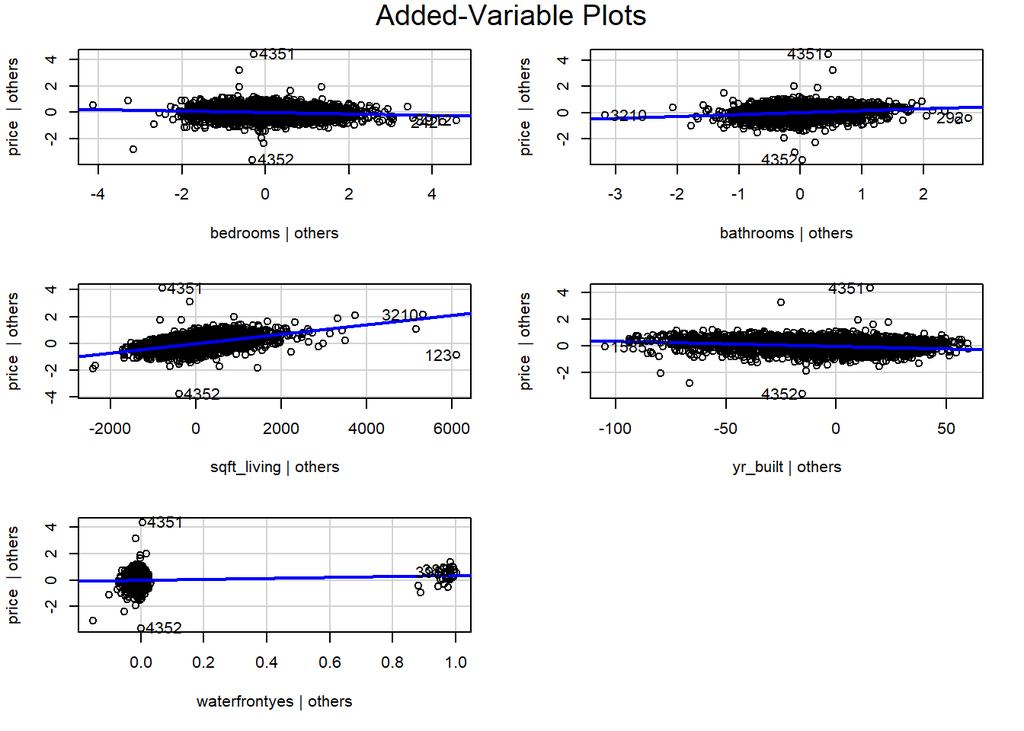

```r
# Added variable plots
avPlots(house.jitter.subset.lm)
```

#### Residuals vs Predictors

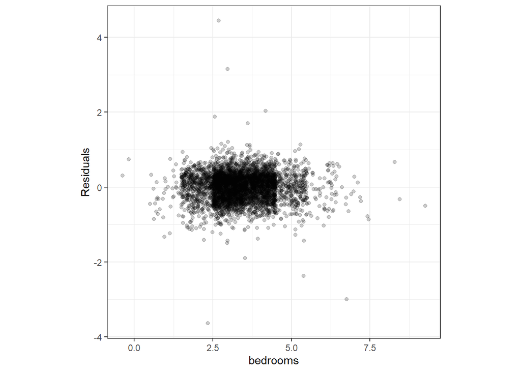

```r
# residuals vs predictors

ggplot(data = house.jitter.subset,
       mapping = aes(x = bedrooms, y = house.subset.lm$residuals)) +
  geom_point(alpha = 0.2) +
  theme_bw() +
  ylab("Residuals") +
  theme(aspect.ratio = 1)
```

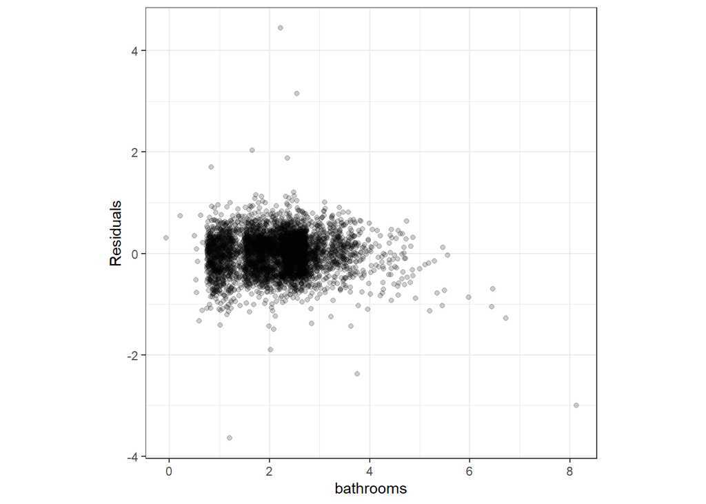

```r
ggplot(data = house.jitter.subset,
       mapping = aes(x = bathrooms, y = house.subset.lm$residuals)) +
  geom_point(alpha = 0.2) +
  theme_bw() +
  ylab("Residuals") +
  theme(aspect.ratio = 1)
```

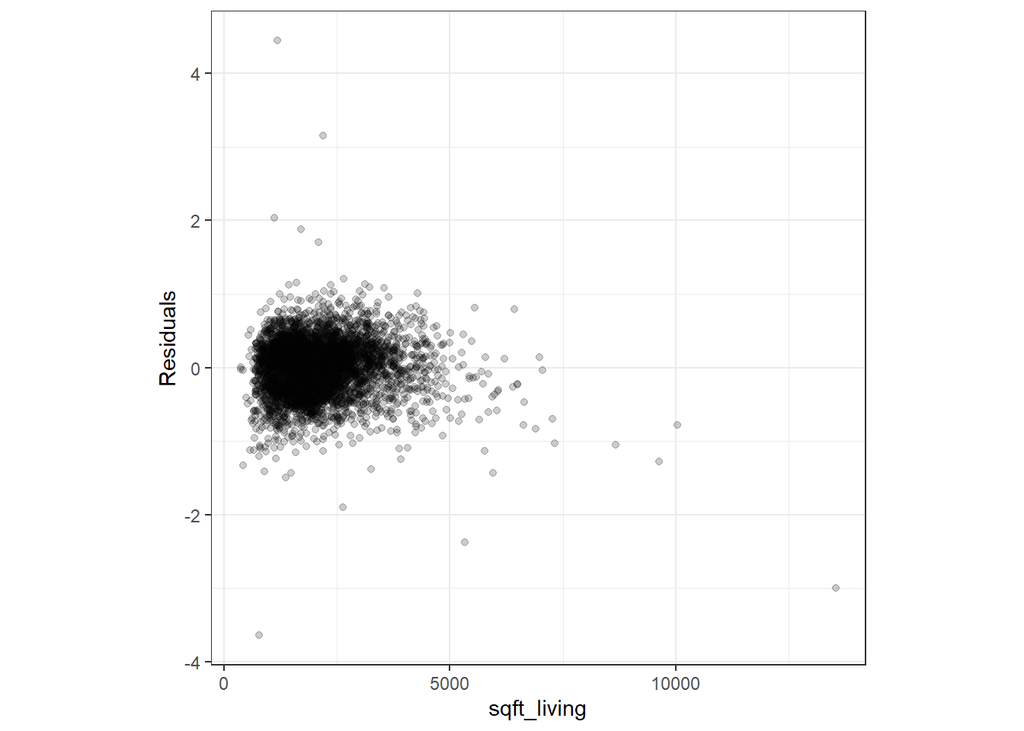

```r
ggplot(data = house.jitter.subset,
       mapping = aes(x = sqft_living, y = house.subset.lm$residuals)) +
  geom_point(alpha = 0.2) +
  theme_bw() +
  ylab("Residuals") +
  theme(aspect.ratio = 1)
```

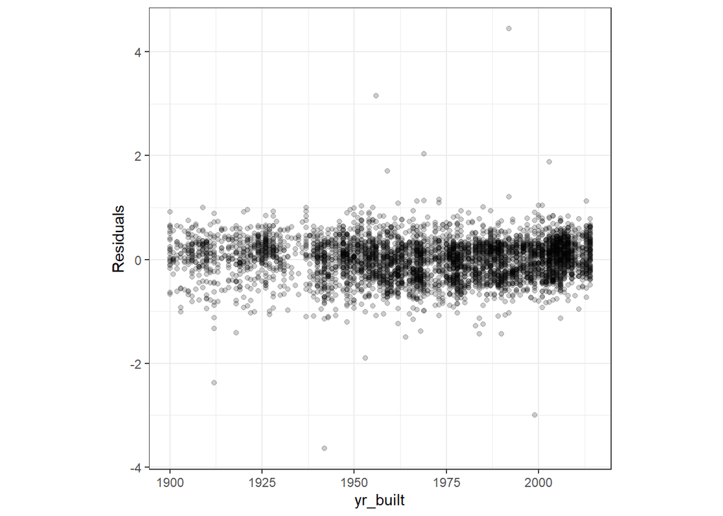

```r
ggplot(data = house.jitter.subset,
       mapping = aes(x = yr_built, y = house.subset.lm$residuals)) +
  geom_point(alpha = 0.2) +
  theme_bw() +
  ylab("Residuals") +
  theme(aspect.ratio = 1)
```

#### Residuals vs Fitted Values

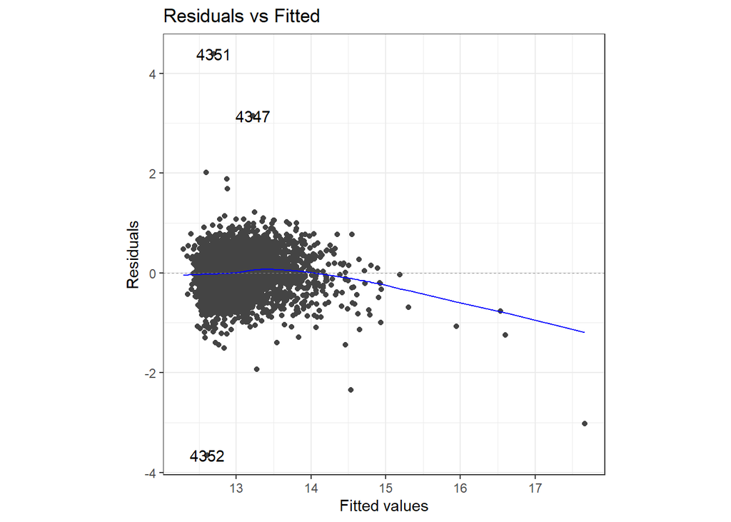

```r
# Residuals vs fitted values
autoplot(house.jitter.subset.lm,
         which = 1,
         ncol = 1,
         nrow = 1) + theme_bw() +
  theme(aspect.ratio = 1) +
  scale_y_continuous()
```

Logging price seemed to fix a lot of problems and produce a better model.

Based on the scatter plot matrix, residuals vs predictors, and residuals vs fitted values plot, the linearity assumption seems met. There is a dip on the right half of the blue line in the residuals vs fitted values plot, but we assume that isn’t concerning because it’s influenced by just a few points.

### Independence

All data were collected independent from each other and at random. This assumption is met.

### Residuals are normally distributed and centered at zero

#### Box Plot

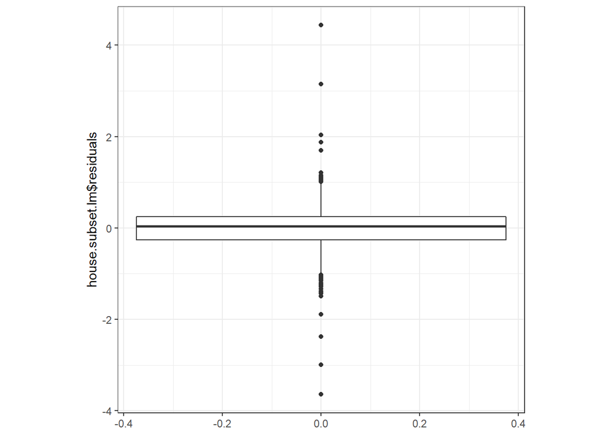

```r
ggplot() +
  geom_boxplot(data = house.subset, mapping = aes(y = house.subset.lm$residuals)) +
  theme_bw() +
  theme(aspect.ratio = 1)
```

#### Histogram

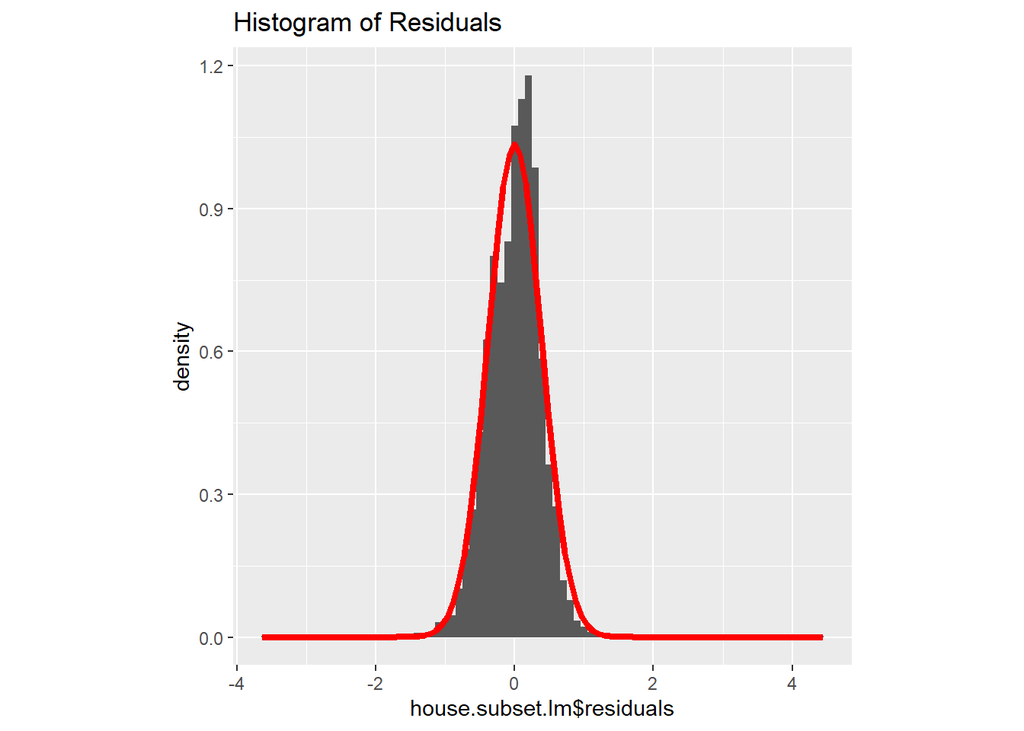

```r
ggplot(data = house.subset, mapping = aes(x = house.subset.lm$residuals)) +
  geom_histogram(mapping = aes(y = ..density..), binwidth = 0.1) +
  stat_function(fun = dnorm,
                color = "red",
                size = 1.5,
                args = list(mean = mean(house.subset.lm$residuals),
                sd = sd(house.subset.lm$residuals))) +
  theme(aspect.ratio = 1) +
  ggtitle("Histogram of Residuals")
```

#### Shaprio Wilke Test

```r
shapiro.test(house.subset.lm$residuals)
```

```
##
##  Shapiro-Wilk normality test
##
## data:  house.subset.lm$residuals
## W = 0.95855, p-value < 2.2e-16
```

Both the box plot and histogram show a roughly equal spread and centered at zero, even though the Shapiro-Wilke test returned a low p-value. This could be due to potential influential points. We are okay saying this assumption is met.

### The residuals have equal variance across all values of the domain

Aside from the potential influential points, the residuals vs fitted values plot seems to be relatively ok. This assumption is met.

### The model describes all observations

#### DFBETAS

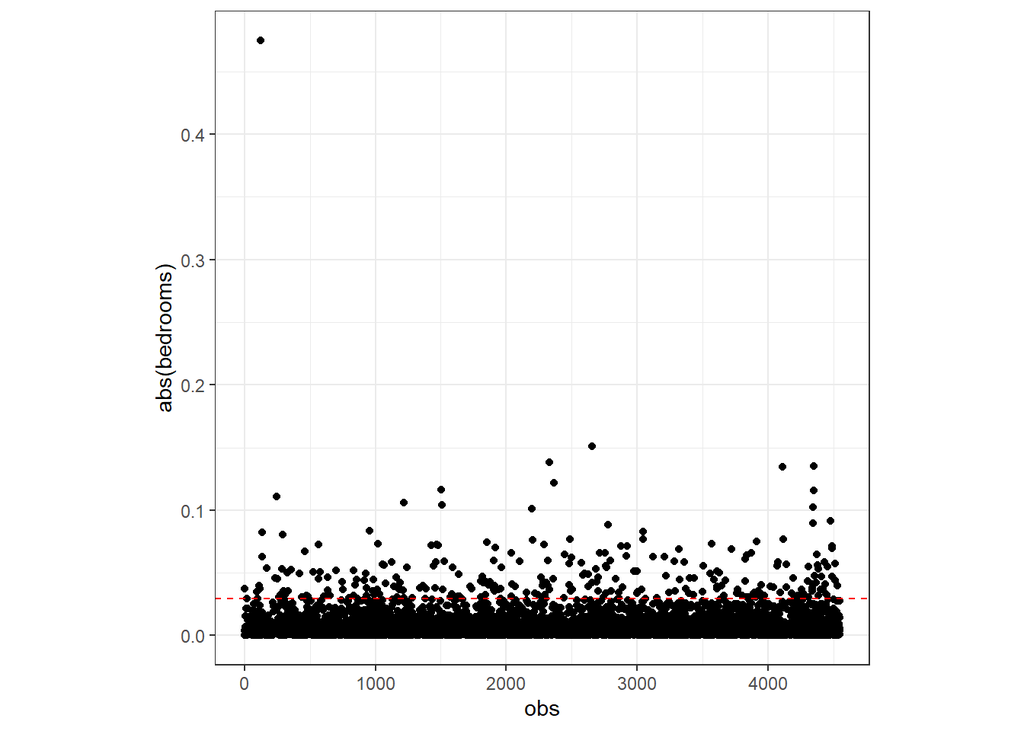

```r
house.subset.dfbetas <- as.data.frame(dfbetas(house.subset.lm))
house.subset.dfbetas$obs <- 1:length(house.subset$price)

ggplot(data = house.subset.dfbetas) +
  geom_point(mapping = aes(x = obs, y = abs(bedrooms))) +
  geom_hline(mapping = aes(yintercept = 2 / sqrt(length(obs))),
             color = "red", linetype = "dashed") +  # for n > 30
  theme_bw() +
  theme(aspect.ratio = 1)
```

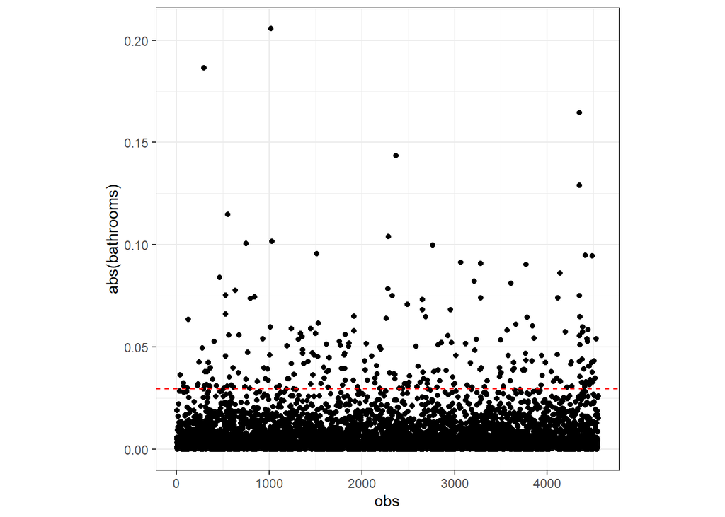

```r
ggplot(data = house.subset.dfbetas) +
  geom_point(mapping = aes(x = obs, y = abs(bathrooms))) +
  geom_hline(mapping = aes(yintercept = 2 / sqrt(length(obs))),
             color = "red", linetype = "dashed") +  # for n > 30
  theme_bw() +
  theme(aspect.ratio = 1)
```

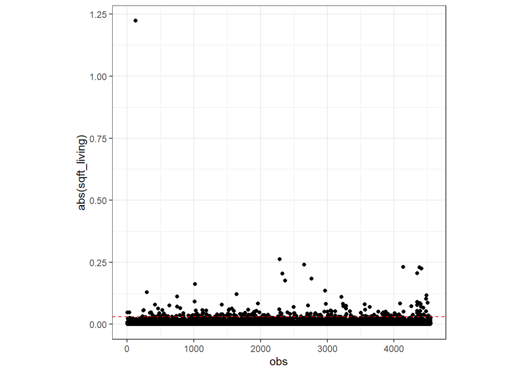

```r
ggplot(data = house.subset.dfbetas) +
  geom_point(mapping = aes(x = obs, y = abs(sqft_living))) +
  geom_hline(mapping = aes(yintercept = 2 / sqrt(length(obs))),
             color = "red", linetype = "dashed") +  # for n > 30
  theme_bw() +
  theme(aspect.ratio = 1)
```

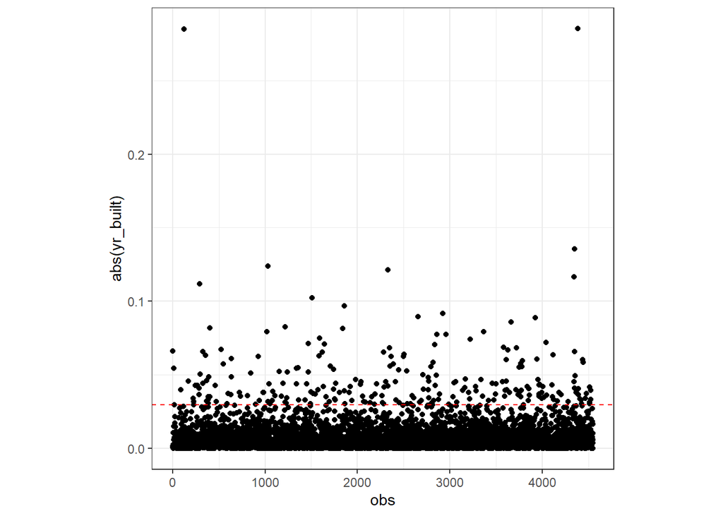

```r
ggplot(data = house.subset.dfbetas) +
  geom_point(mapping = aes(x = obs, y = abs(yr_built))) +
  geom_hline(mapping = aes(yintercept = 2 / sqrt(length(obs))),
             color = "red", linetype = "dashed") +  # for n > 30
  theme_bw() +
  theme(aspect.ratio = 1)
```

#### DFFITS

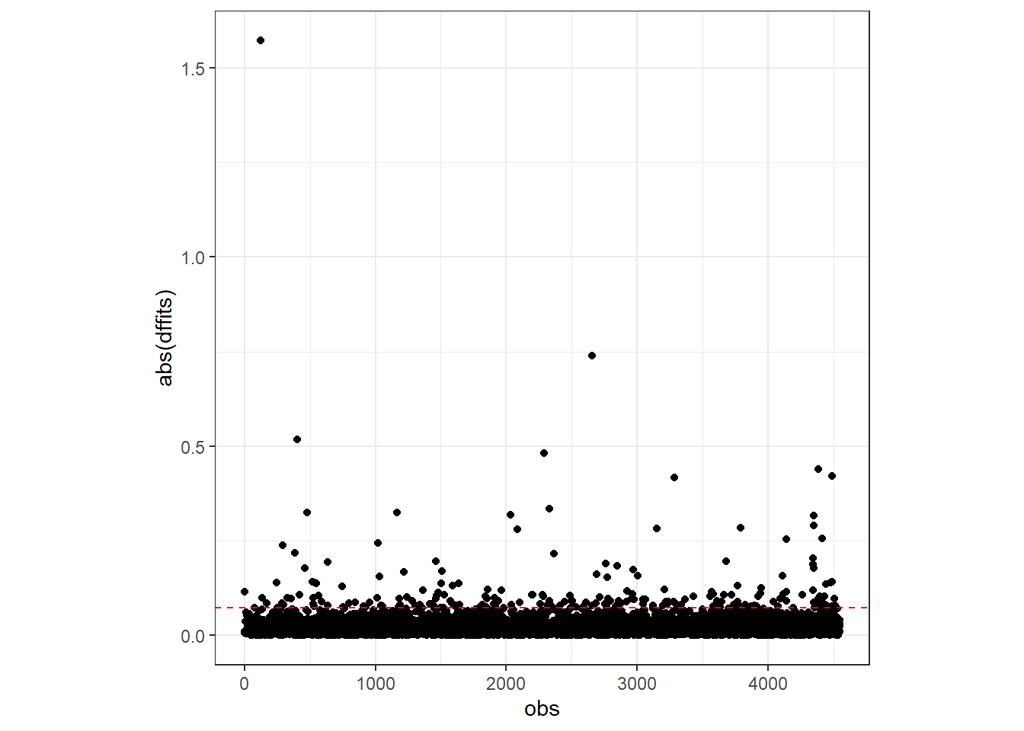

```r
house.subset.dffits <- data.frame("dffits" = dffits(house.subset.lm))
house.subset.dffits$obs <- 1:length(house.subset$price)

ggplot(data = house.subset.dffits) +
  geom_point(mapping = aes(x = obs, y = abs(dffits))) +
  geom_hline(mapping = aes(yintercept = 2 *
                             sqrt(length(house.subset.lm$coefficients) /
                                    length(obs))),
             color = "red", linetype = "dashed") +
  theme_bw() +
  theme(aspect.ratio = 1)
```

```r
dffits <- house.subset.dffits[abs(house.subset.dffits$dffits)
                              > 2 * sqrt(length(house.subset.lm$coefficients)
                                         / length(house.subset.dffits$obs)), ]
dffits$dffits <- abs(dffits$dffits) # This makes all dffits positive so the next
                                      # operation is easier

head(dffits[order(-dffits$dffits), ]) # This code orders the dffits dataframe
```

```
##         dffits  obs
## 123  1.5721823  123
## 2655 0.7401115 2655
## 405  0.5188648  405
## 2287 0.4809641 2287
## 4399 0.4387711 4385
## 4530 0.4218910 4492
```

```r
                                        # in descending order by dffits
```

#### Cook’s Distance

```r
cooksd <- as.data.frame(cooks.distance(house.subset.lm))
names(cooksd)[1] <- "distance" # Changes the name of the column to something prettier

cooksd.temp <- as.data.frame(cooksd[cooksd$distance >= 4/length(cooksd$distance),])
names(cooksd.temp)[1] <- "distance" # Changes the name of the column to something prettier

head(cooksd.temp[order(-cooksd.temp$distance), ])
```

```
## [1] 0.40634844 0.09108192 0.04480522 0.03852578 0.03182389 0.02963931
```

```r
house.subset.new <- house.subset[-c(123),]

house.subset.new.lm <- lm(house.subset.new)

house.jitter.subset.new <- house.subset[-c(123),]

house.jitter.subset.new.lm <- lm(house.jitter.subset.new)
```

Then, we will recheck this assumption.

#### DFBETAS

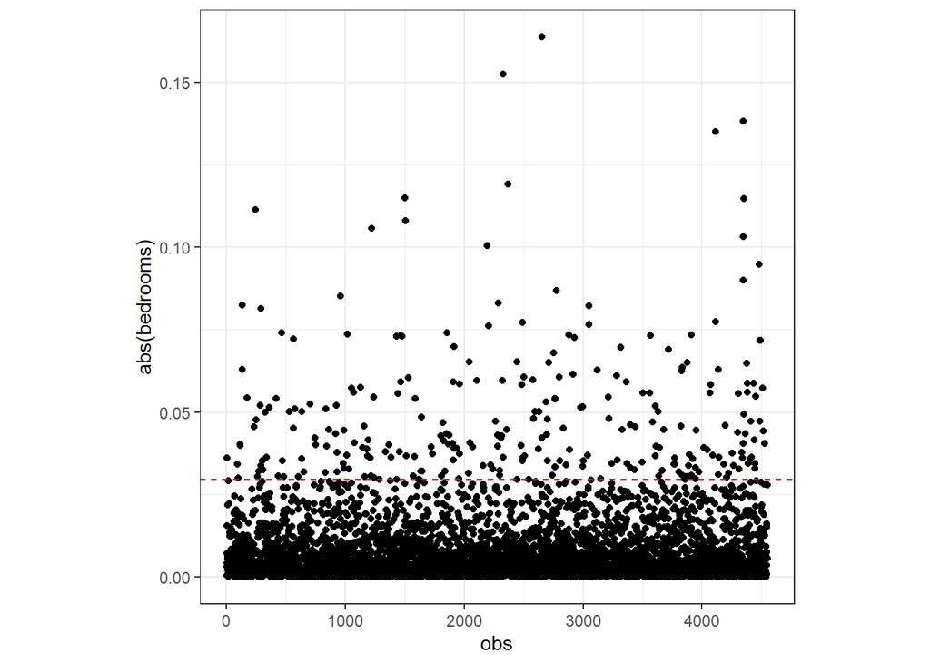

```r
house.subset.new.dfbetas <- as.data.frame(dfbetas(house.subset.new.lm))
house.subset.new.dfbetas$obs <- 1:length(house.subset.new$price)

ggplot(data = house.subset.new.dfbetas) +
  geom_point(mapping = aes(x = obs, y = abs(bedrooms))) +
  geom_hline(mapping = aes(yintercept = 2 / sqrt(length(obs))),
             color = "red", linetype = "dashed") +  # for n > 30
  theme_bw() +
  theme(aspect.ratio = 1)
```

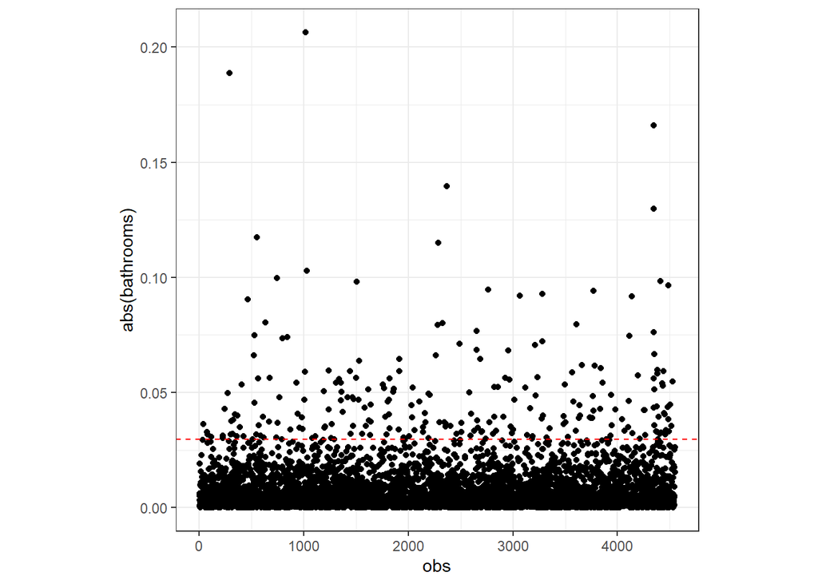

```r
ggplot(data = house.subset.new.dfbetas) +
  geom_point(mapping = aes(x = obs, y = abs(bathrooms))) +
  geom_hline(mapping = aes(yintercept = 2 / sqrt(length(obs))),
             color = "red", linetype = "dashed") +  # for n > 30
  theme_bw() +
  theme(aspect.ratio = 1)
```

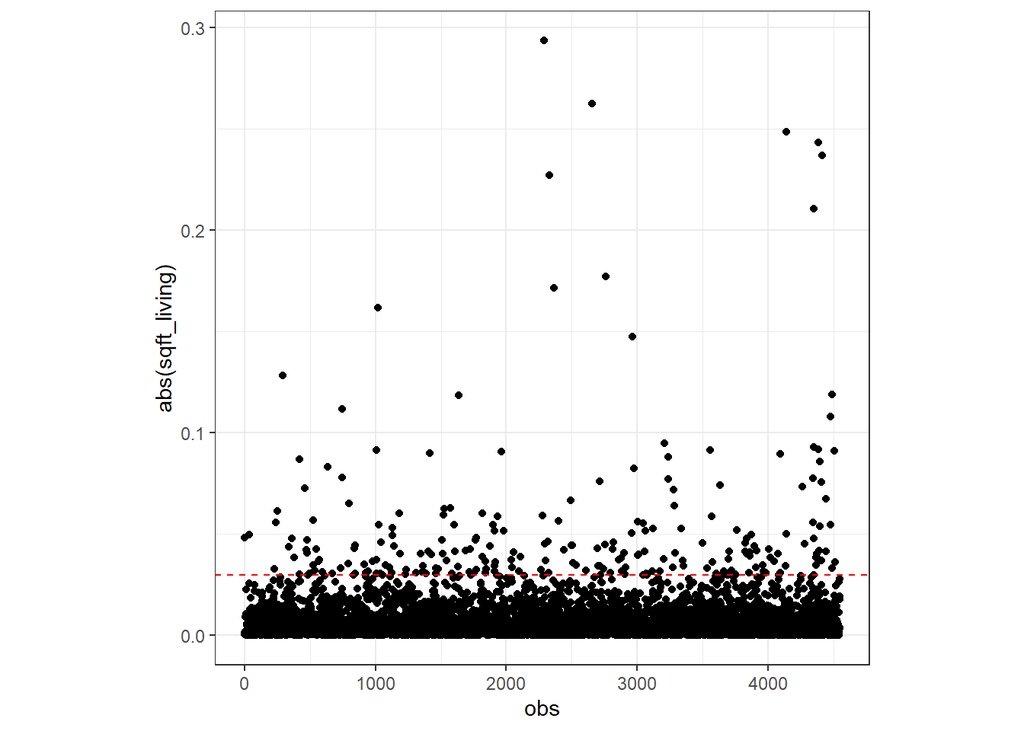

```r
ggplot(data = house.subset.new.dfbetas) +
  geom_point(mapping = aes(x = obs, y = abs(sqft_living))) +
  geom_hline(mapping = aes(yintercept = 2 / sqrt(length(obs))),
             color = "red", linetype = "dashed") +  # for n > 30
  theme_bw() +
  theme(aspect.ratio = 1)
```

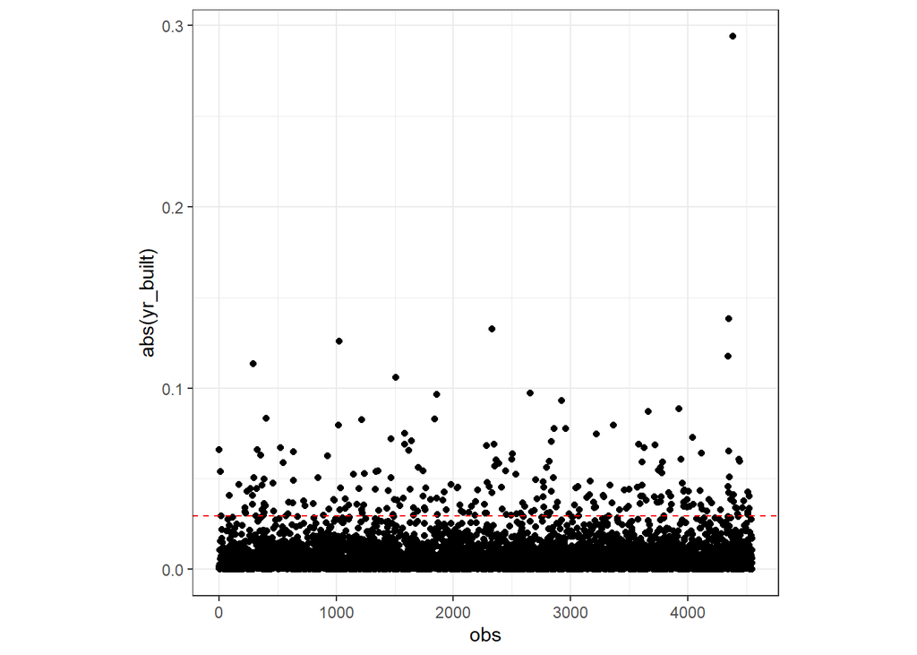

```r
ggplot(data = house.subset.new.dfbetas) +
  geom_point(mapping = aes(x = obs, y = abs(yr_built))) +
  geom_hline(mapping = aes(yintercept = 2 / sqrt(length(obs))),
             color = "red", linetype = "dashed") +  # for n > 30
  theme_bw() +
  theme(aspect.ratio = 1)
```

#### DFFITS

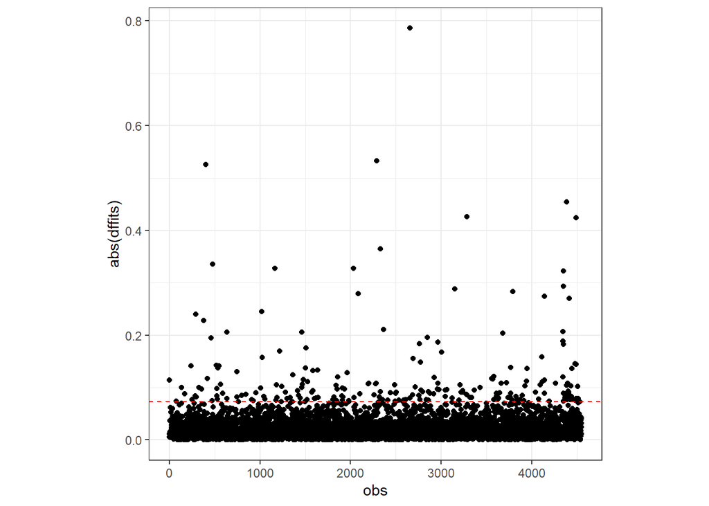

```r
house.subset.new.dffits <- data.frame("dffits" = dffits(house.subset.new.lm))
house.subset.new.dffits$obs <- 1:length(house.subset.new$price)

ggplot(data = house.subset.new.dffits) +
  geom_point(mapping = aes(x = obs, y = abs(dffits))) +
  geom_hline(mapping = aes(yintercept = 2 *
                             sqrt(length(house.subset.new.lm$coefficients) /
                                    length(obs))),
             color = "red", linetype = "dashed") +
  theme_bw() +
  theme(aspect.ratio = 1)
```

```r
dffits <- house.subset.new.dffits[abs(house.subset.new.dffits$dffits)
                              > 2 * sqrt(length(house.subset.new.lm$coefficients)
                                         / length(house.subset.new.dffits$obs)), ]
dffits$dffits <- abs(dffits$dffits) # This makes all dffits positive so the next
                                      # operation is easier

head(dffits[order(-dffits$dffits), ]) # This code orders the dffits dataframe
```

```
##         dffits  obs
## 2655 0.7861472 2654
## 2287 0.5322381 2286
## 405  0.5253082  404
## 4399 0.4544194 4384
## 3284 0.4261182 3283
## 4530 0.4242010 4491
```

```r
                                        # in descending order by dffits
```

#### Cook’s Distance

```r
cooksd <- as.data.frame(cooks.distance(house.subset.new.lm))
names(cooksd)[1] <- "distance" # Changes the name of the column to something prettier

cooksd.temp <- as.data.frame(cooksd[cooksd$distance >= 4/length(cooksd$distance),])
names(cooksd.temp)[1] <- "distance" # Changes the name of the column to something prettier

head(cooksd.temp[order(-cooksd.temp$distance), ])
```

```
## [1] 0.10273440 0.04716828 0.04592303 0.03412144 0.03023672 0.02996441
```

After removing observation 123, the DFFITS and DFBETAS show that the model describes all observations.

### No additional predictors needed

We would need to understand the data more, but the given predictors from the dataset seemed fairly comprehensive. If our variable selection process worked, then we shouldn’t need any more predictor variables.

### No multicollinearity

```r
house.only.continuous <- house.subset.new[, 1:5]

round(cor(house.only.continuous), 2)
```

```
##             price bedrooms bathrooms sqft_living yr_built
## price        1.00     0.35      0.55        0.67     0.06
## bedrooms     0.35     1.00      0.55        0.60     0.14
## bathrooms    0.55     0.55      1.00        0.75     0.47
## sqft_living  0.67     0.60      0.75        1.00     0.29
## yr_built     0.06     0.14      0.47        0.29     1.00
```

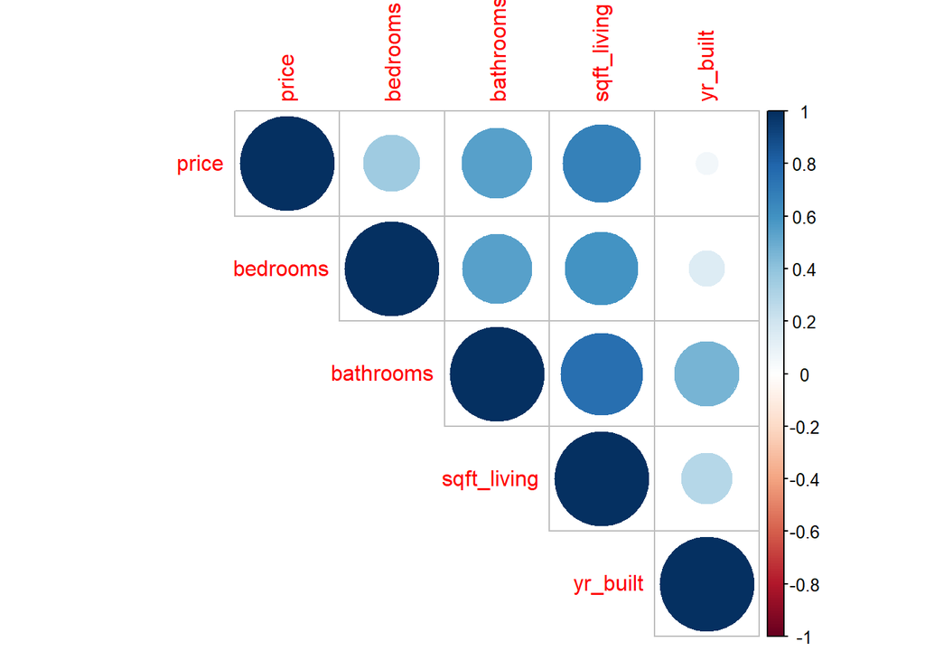

```r
corrplot(cor(house.only.continuous), type = "upper")
```

```r
house.subset.new.vifs <- vif(house.subset.new.lm)
house.subset.new.vifs
```

```
##    bedrooms   bathrooms sqft_living    yr_built  waterfront
##    1.643046    2.883697    2.656200    1.319242    1.025622
```

```r
max(house.subset.new.vifs)
```

```
## [1] 2.883697
```

```r
mean(house.subset.new.vifs)
```

```
## [1] 1.905561
```

The correlation plot wasn’t very concerning. The VIFs output showed that there were no multicollinearity issues.

## The linearity assumptions are met

# Checking for interations

Rather than checking for all possible combinations of interactions, we will just add those that make logical sense in the context of the data set. First, we will add all the noted interactions. Then, we will remove those that don’t have a low p-value. Finally, we will run an anova test to see if any removed interactions had a significant effect on predicting house price.

```r
house.all.inter <- lm(price ~ bedrooms + bathrooms + sqft_living +
                        yr_built + waterfront +
                        bedrooms*bathrooms +
                        sqft_living*bedrooms +
                        sqft_living*bathrooms +
                        waterfront*sqft_living,
                      data=house.subset.new)

summary(house.all.inter)
```

```
##
## Call:
## lm(formula = price ~ bedrooms + bathrooms + sqft_living + yr_built +
##     waterfront + bedrooms * bathrooms + sqft_living * bedrooms +
##     sqft_living * bathrooms + waterfront * sqft_living, data = house.subset.new)
##
## Residuals:
##     Min      1Q  Median      3Q     Max
## -3.5470 -0.2452  0.0289  0.2401  4.4727
##
## Coefficients:
##                             Estimate Std. Error t value Pr(>|t|)
## (Intercept)                2.046e+01  4.252e-01  48.112  < 2e-16 ***
## bedrooms                  -7.162e-02  2.117e-02  -3.383 0.000724 ***
## bathrooms                  3.521e-01  3.757e-02   9.372  < 2e-16 ***
## sqft_living                4.605e-04  3.345e-05  13.768  < 2e-16 ***
## yr_built                  -4.357e-03  2.214e-04 -19.680  < 2e-16 ***
## waterfrontyes              5.238e-01  1.356e-01   3.864 0.000113 ***
## bedrooms:bathrooms        -1.980e-02  1.019e-02  -1.944 0.051981 .
## bedrooms:sqft_living       1.352e-05  9.275e-06   1.457 0.145050
## bathrooms:sqft_living     -5.060e-05  7.081e-06  -7.145 1.04e-12 ***
## sqft_living:waterfrontyes -3.558e-05  3.552e-05  -1.002 0.316543
## ---
## Signif. codes:  0 '***' 0.001 '**' 0.01 '*' 0.05 '.' 0.1 ' ' 1
##
## Residual standard error: 0.3778 on 4540 degrees of freedom
## Multiple R-squared:  0.5158, Adjusted R-squared:  0.5148
## F-statistic: 537.3 on 9 and 4540 DF,  p-value: < 2.2e-16
```

```r
temp <- lm(price ~ bedrooms + bathrooms + sqft_living +
                    yr_built + waterfront +
                    sqft_living*bathrooms,
                   data=house.subset.new)

anova(house.all.inter, temp)
```

```
## Analysis of Variance Table
##
## Model 1: price ~ bedrooms + bathrooms + sqft_living + yr_built + waterfront +
##     bedrooms * bathrooms + sqft_living * bedrooms + sqft_living *
##     bathrooms + waterfront * sqft_living
## Model 2: price ~ bedrooms + bathrooms + sqft_living + yr_built + waterfront +
##     sqft_living * bathrooms
##   Res.Df    RSS Df Sum of Sq      F Pr(>F)
## 1   4540 647.91
## 2   4543 648.55 -3  -0.63838 1.4911 0.2148
```

At least one interaction between sqft_living and bathrooms is significant and the interactions between bedrooms/bathrooms, sqft_living/waterfront, and bedrooms/sqft_living were not significant.

Since there was no significant difference in only keeping the interaction between sqft_living and bathrooms versus all the above interactions, we will keep that as our final interaction model.

```r
house.inter <- temp
summary(house.inter)
```

```
##
## Call:
## lm(formula = price ~ bedrooms + bathrooms + sqft_living + yr_built +
##     waterfront + sqft_living * bathrooms, data = house.subset.new)
##
## Residuals:
##     Min      1Q  Median      3Q     Max
## -3.5475 -0.2472  0.0295  0.2407  4.4773
##
## Coefficients:
##                         Estimate Std. Error t value Pr(>|t|)
## (Intercept)            2.042e+01  4.241e-01  48.143  < 2e-16 ***
## bedrooms              -8.563e-02  8.092e-03 -10.581  < 2e-16 ***
## bathrooms              2.893e-01  1.657e-02  17.463  < 2e-16 ***
## sqft_living            5.148e-04  1.757e-05  29.304  < 2e-16 ***
## yr_built              -4.318e-03  2.200e-04 -19.627  < 2e-16 ***
## waterfrontyes          4.114e-01  7.036e-02   5.847 5.37e-09 ***
## bathrooms:sqft_living -5.341e-05  4.923e-06 -10.849  < 2e-16 ***
## ---
## Signif. codes:  0 '***' 0.001 '**' 0.01 '*' 0.05 '.' 0.1 ' ' 1
##
## Residual standard error: 0.3778 on 4543 degrees of freedom
## Multiple R-squared:  0.5153, Adjusted R-squared:  0.5147
## F-statistic:   805 on 6 and 4543 DF,  p-value: < 2.2e-16
```

# Model assesment via model evaluation metrics

### MSE

```r
model_summ<- summary(house.inter)
mean(model_summ$residuals^2)
```

```
## [1] 0.1425387
```

### RMSE

```r
sqrt(mean(model_summ$residuals^2))
```

```
## [1] 0.3775429
```

The average error performed by the model in predicting price (log scale) is 0.3775429.

### Multiple R-Squared

```r
summary(house.inter)$r.squared
```

```
## [1] 0.5152985
```

51.53% of the variability in the model is explained by the predictors.

### Adjusted R-Squared

```r
summary(house.inter)$adj.r.squared
```

```
## [1] 0.5146583
```

51.47% of the variability in the model is explained by the predictors, when accounting for the number of predictors.

### F-Statistic

```r
summary(house.inter)$fstatistic
```

```
##     value     numdf     dendf
##  804.9631    6.0000 4543.0000
```

There is a significant linear relationship between house price (log scale) and the predictors in the model.

# Statistical Inference

### Confidence interval for slopes

```r
exp(confint(house.inter, level= 0.95)) # Convert back from the log scale
```

```
##                              2.5 %       97.5 %
## (Intercept)           3.202838e+08 1.689165e+09
## bedrooms              9.034859e-01 9.326136e-01
## bathrooms             1.292789e+00 1.379547e+00
## sqft_living           1.000481e+00 1.000549e+00
## yr_built              9.952625e-01 9.961213e-01
## waterfrontyes         1.314450e+00 1.732027e+00
## bathrooms:sqft_living 9.999369e-01 9.999562e-01
```

### Confidence interval for house with 5 bedrooms, 3 bathrooms, 4500 square feet of living space, built in 2015, and on the waterfront

```r
confidence <-
  predict(house.inter,
          newdata=data.frame(bedrooms=5,
                             bathrooms=3,
                             sqft_living=4500,
                             yr_built=2015,
                             waterfront="yes"),
          interval="confidence",
          level=.95)

exp(confidence) # Convert back from the log scale
```

```
##       fit     lwr     upr
## 1 1415637 1230638 1628448
```

We are 95% confident that the average price for houses with 5 bedrooms, 3 bathrooms, 4,500 square feet of living space, built in the year 2015, and on the waterfront is between 1,230,638 and 1,628,448 dollars.

### Prediction interval for house with 5 bedrooms, 3 bathrooms, 4500 square feet of living space, built in 2015, and on the waterfront

```r
prediction <-
  predict(house.inter,
          newdata=data.frame(bedrooms=5,
                             bathrooms=3,
                             sqft_living=4500,
                             yr_built=2015,
                             waterfront="yes"),
          interval="prediction",
          level=.95)

exp(prediction) # Convert back from the log scale
```

```
##       fit      lwr     upr
## 1 1415637 666123.2 3008497
```

We are 95% confident that the price for a house with 5 bedrooms, 3 bathrooms, 4,500 square feet of living space, built in the year 2015, and on the waterfront is between 666,123.2 and 3,008,497 dollars.

# Summary and conclusions

Additionally, we also found that square feet of basement space, square feet of lot space, views a house has, the number of floors a house has, condition of the house, square footage above ground, and if it was renovated does not have as significant impact on house prices as the previously discussed variables. This is beneficial for people in the market to buy a home, as they are more capable of knowing whether or not they are getting a good deal.